# Gamma Spectroscopy

*This document needs to be individually filled out by each student and handed in for grading. Once all task are filled out and questions answered, this document is equivalent to handing in a lab report. IN order to save changes that you make, remember to save the document before closing it!*

**In the code cells, whenever you see the comment " -> TODO <- " This means that you need to edit or add something to that row in the code. Read the relevant comment which follows.**

### Importing python packages

```python
#This code cell holds useful code neede for the analysis. Execute it like normal.
# Packages to help importing files
import sys, os
sys.path.append('./lib')

# Package that supports working with large arrays
import numpy as np

# Package for plotting
import matplotlib   # choose a backend for web applications; remove for stand-alone applications:
matplotlib.use('Agg') # enable interactive notebook plots (alternative: use 'inline' instead of 'notebook'/'widget' for static images)
%matplotlib notebook

# The following line is the ONLY one needed in stand-alone applications!
import matplotlib.pyplot as plt

# Function that fits a curve to data
from scipy.optimize import curve_fit

# Custom pakages prepared for you to analyze experimental data from labs.
# The code is located in the 'lib' subfolder which we have to specify:
sys.path.append('./lib')
import MCA, fittingFunctions
```

## Task 1: Cs-137 and Co-60 gamma-spectra

### Step 4: Import your data and plot the spectra in Jupyter Notebook.

```python
#Load your data files here:
Cs137 = MCA.load_spectrum("Cs-137.Spe") #-> TODO <- Insert the name of your data file. Source: Cs-137
Co60 = MCA.load_spectrum("CO-60.spe")   #-> TODO <- Insert the name of your data file. Source: Co-60
```

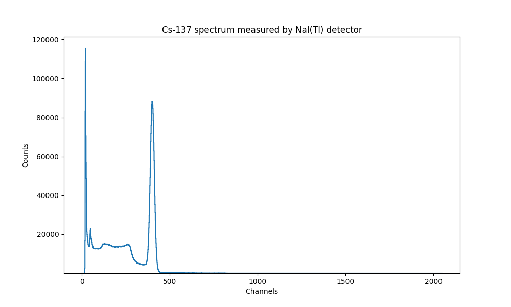

```
(1.0, 121395.75)
```

```python
#Execute this cell to make plot of Cs-137 spectra

#### NO NEED TO EDIT ####
plt.figure(0, figsize=(10, 6)) #make figure for Cs-137 data.
plt.step(Cs137.bin_centers, Cs137.counts, where='mid', label='step') #make a stepped plot
plt.title("Cs-137 spectrum measured by NaI(Tl) detector") # set title of the plot
plt.xlabel("Channels")     # set label for x-axis
plt.ylabel("Counts")       # set label for y-axis
#plt.yscale('log')          # show the y-axis in logarithmic scale
plt.ylim(ymin=1)           # used to limit the minimum value shown on the y-axis
#plt.savefig("test_spectrum.png") #This is how you can save the figure
#########################
```

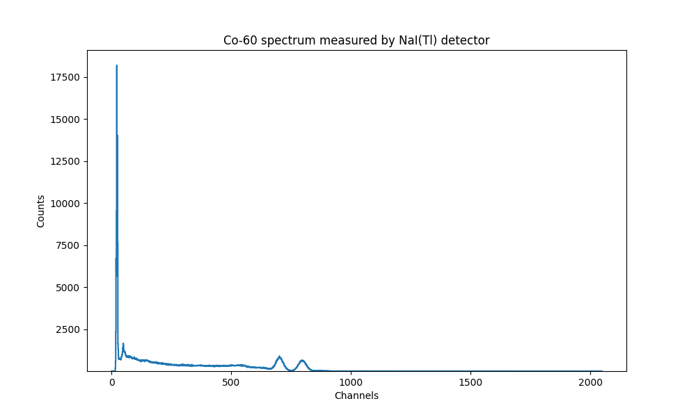

```
(1.0, 19106.85)
```

```python
#Execute this cell to make plot of Co-60 spectra

#### NO NEED TO EDIT ####
plt.figure(1, figsize=(10, 6)) #make figure for Co-60 data.
plt.step(Co60.bin_centers, Co60.counts, where='mid', label='step') #make a stepped plot
plt.title("Co-60 spectrum measured by NaI(Tl) detector") # set title of the plot
plt.xlabel("Channels")     # set label for x-axis
plt.ylabel("Counts")       # set label for y-axis
#plt.yscale('log')          # show the y-axis in logarithmic scale
plt.ylim(ymin=1)           # used to limit the minimum value shown on the y-axis
#plt.savefig("test_spectrum.png") #This is how you can save the figure
#########################
```

### Task 1: Questions:

(double click to edit, shift+ENTER to execute changes)

**Question 1**: Where are the full energy peaks on the spectra and what do they represent?

**->** Cobalt: One energy peak at 800 and one at 700, these represent the enrgy values with the most measurements. The rightmost peak represents decay from 2+ to 0+ and the one at 700 represents decay from 4+ to 2+. Releases negative Beta radiation, as the proton number increases

CS-137: One peak at 400, this represents decay from 2+ to 0+. Negative Beta radiation, as the proton number increases.

The peaks mentioned represent full energy peaks, where all of the energy is transmitted to the detector. Perhaps through fotoelectric effect or pair production with no escape. This does not always happens, whcih is why one can se a lot of background noise. A full energy peak can also be created by multiple compton scatterings.

**Question 2**: How can we calibrate our detectors, i.e. convert from channels to Energy on to the x-axis?

**->** Use a material with known energy levels, such as cobalt, and convert our energy peaks to the energy of the radiation with a linear relationship E = k*ch + m

### Step 5: Fit a Gaussian function to the relevant peaks and save the centroid values (we will use these for calibration in the next task).

A gaussian function looks like this: $$G(x) = A\cdot e^{\frac{(x-\mu)^2}{2\sigma^2}}$$ where

- $A$ is a constant determing the amplitude of the peak,
- $\mu$ is the mean value of the peak (centroid),
- $\sigma$ is the standard diviation of the peak (width of the peak).

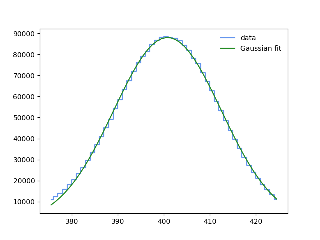

```
Estimated parameters:
 A = 87990.30142, mu = 400.81564,  sigma = 11.69302

Uncertainties in the estimated parameters:
 σ²(A) = 53384.85568, σ²(mu) = 0.00125, σ²(sigma) = 0.00140

Covariance matrix:
 [[ 5.33848557e+04 -5.87978984e-02 -5.13704343e+00]
 [-5.87978984e-02  1.25289159e-03  2.05566607e-05]
 [-5.13704343e+00  2.05566607e-05  1.40137933e-03]]
```

```python
# Fitting the Cs-137 peak:

# In order to make a fit the software needs an intial guess of the parameters of the gaussian.
Cs137_peak = fittingFunctions.perform_Gaussian_fit(x=Cs137.bin_centers, # your x data
                                              y=Cs137.counts,           # your y data
                                              region_start=375,   # -> TODO <- Insert channel number from where to START fitting.
                                              region_stop=425,    # -> TODO <- Insert channel number from where to STOP fitting.
                                              mu_guess=400,       # -> TODO <- Insert intial guess of peak centroid (mean value of the peak)
                                              A_guess=88500,      # -> TODO <- Insert intial guess for the constant 'A' (amplitude of the peak)
                                              sigma_guess=10)     # -> TODO <- Insert intial guess for the standard diviation (width of the peak)

#After executing this cell (Shift + Enter) the fitted parameters can be seen below the plot.
```

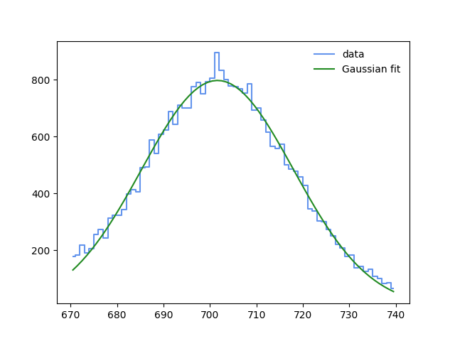

```
Estimated parameters:
 A = 797.00522, mu = 701.62366,  sigma = 16.36385

Uncertainties in the estimated parameters:
 σ²(A) = 39.53591, σ²(mu) = 0.02228, σ²(sigma) = 0.02519

Covariance matrix:
 [[ 3.95359053e+01  2.06347597e-02 -5.93912335e-01]
 [ 2.06347597e-02  2.22795320e-02 -1.13222334e-03]
 [-5.93912335e-01 -1.13222334e-03  2.51941666e-02]]
```

```python
# Fitting the first peak of Co-60:

# In order to make a fit the software needs an intial guess of the parameters of the gaussian.
Co60_peak1 = fittingFunctions.perform_Gaussian_fit(x=Co60.bin_centers, # your x data
                                              y=Co60.counts,           # your y data
                                              region_start=670,   # -> TODO <- Insert channel number from where to START fitting.
                                              region_stop=740,    # -> TODO <- Insert channel number from where to STOP fitting.
                                              mu_guess=700,       # -> TODO <- Insert intial guess of peak centroid (mean value of the peak)
                                              A_guess=850,      # -> TODO <- Insert intial guess for the constant 'A' (amplitude of the peak)
                                              sigma_guess=27)     # -> TODO <- Insert intial guess for the standard diviation (width of the peak)

#After executing this cell (Shift + Enter) the fitted parameters can be seen below the plot.
```

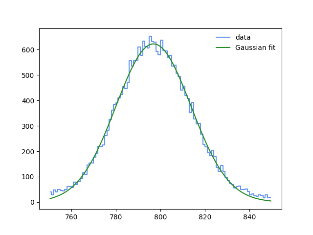

```
Estimated parameters:
 A = 622.75539, mu = 796.88462,  sigma = 16.84438

Uncertainties in the estimated parameters:
 σ²(A) = 14.15663, σ²(mu) = 0.01380, σ²(sigma) = 0.01388

Covariance matrix:
 [[ 1.41566274e+01  3.86779595e-04 -2.56315737e-01]
 [ 3.86779595e-04  1.37970584e-02 -2.39126701e-05]
 [-2.56315737e-01 -2.39126701e-05  1.38763216e-02]]
```

```python
# Fitting the second peak of Co-60:

# In order to make a fit the software needs an intial guess of the parameters of the gaussian.
Co60_peak2 = fittingFunctions.perform_Gaussian_fit(x=Co60.bin_centers, # your x data
                                              y=Co60.counts,           # your y data
                                              region_start=750,   # -> TODO <- Insert channel number from where to START fitting.
                                              region_stop=850,    # -> TODO <- Insert channel number from where to STOP fitting.
                                              mu_guess=795,       # -> TODO <- Insert intial guess of peak centroid (mean value of the peak)
                                              A_guess=625,      # -> TODO <- Insert intial guess for the constant 'A' (amplitude of the peak)
                                              sigma_guess=20)     # -> TODO <- Insert intial guess for the standard diviation (width of the peak)

#After executing this cell (Shift + Enter) the fitted parameters can be seen below the plot.
```

### Task 2: Energy calibration the NaI-scintillator detector

Recall that the energy calibration is the linear dependence between the ADC channel number and energies of full-energy peaks of a spectrum. It should be performed with a linear regression. Therefore, the idea behind it can be expressed as:

\begin{equation*} Energy = k \cdot channel + m \end{equation*}

where $Energy$ is characteristic $\gamma$-ray energy for a source and can be found from the KF6-RadionuclideTable-Gamma.pdf, $channel$ is a channel number that corresponds to a peak centroid of uncalibrated spectrum, $k$ and $m$ are calibration constants.

### Step 1: Based on the centroid values from the three peaks in the Cs-137 and Co-60 spectra, create an energy calibration curve. Recall that the energy calibration is the linear dependence between the ADC channel number and the energies of the identified full-energy peaks. It is performed with a linear function.

A linear function looks like: $$Energy = k \cdot Channel + m$$ where;

- $k$ determines the slope of the curve,
- $m$ determined the intersection of the y-axis.

Find calibration constants for NaI(Tl) detector:

```
Gamma energies [keV]: [ 661.65 1173.2  1332.5 ]
Fitted centroid values [ADC]: [400.81563555 701.62365718 796.88462241]
```

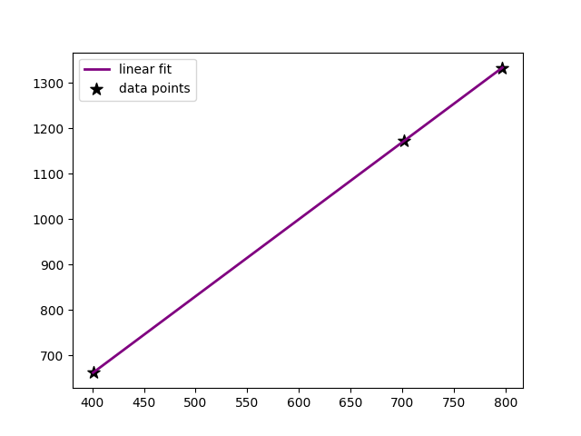

```
Estimated paramters (k, m) = (1.69541, -17.59677)
```

```python
#First, lets put in the relevant gamma energies for Co-60 and Cs-137 (source: https://www.nndc.bnl.gov/nudat2/dec_searchi.jsp)
Table_E_Cs137 = np.asarray([0.66165*(10**3)])           # -> TODO <- Insert energy of the Cs-137 peak [keV]
Table_E_Co60 = np.asarray([ 1.1732*(10**3),1.3325*(10**3) ]) # -> TODO <- Insert energies of the two Co-60 peaks [keV]

#### NO NEED TO EDIT ####
Table_E = np.concatenate([Table_E_Cs137, Table_E_Co60]) #put all energies into one container 'Table_E' for ease of use
mu_Cs137 = np.asarray([Cs137_peak.mu]) #save fitted centroid value for Cs-137
mu_Co60 = np.asarray([Co60_peak1.mu, Co60_peak2.mu]) #save fitted centroid values for Co-60
mu_calibration = np.concatenate([mu_Cs137, mu_Co60]) #put all fitted centroid values in one container 'mu_calibration' for ease of use

print(f'Gamma energies [keV]: {Table_E}')
print(f'Fitted centroid values [ADC]: {mu_calibration}')
#########################

# Same as before, the linear function needs intial guess for the two pramters:
k_guess = 2 # -> intial guess for the slope of the curve
m_guess = 1 # -> initial guess for the intersection of the y-axis

#### NO NEED TO EDIT ####
# Perform the fit
estimates_NaI, covar_matrix = curve_fit(fittingFunctions.LineFunc, # name of the function - linear function in our case
                                        mu_calibration,            # our x data - peak centroids
                                        Table_E,                   # our y data - energies
                                        p0 = [k_guess, m_guess])   # our initial guessesfor k and m parameters

k = estimates_NaI[0] #save fitted parameter 'k'
m = estimates_NaI[1] #save fitted parameter 'm'
plt.figure() #make figure
plt.plot(mu_calibration, fittingFunctions.LineFunc(mu_calibration, estimates_NaI[0], estimates_NaI[1]), color='purple', lw=2, label='linear fit') #plot the linear fit
plt.scatter(mu_calibration, Table_E, s=100, c='black', marker='*', label='data points') #plot the fitted data
plt.legend(loc='upper left') #set a legend and its position
plt.show()
print(f"Estimated paramters (k, m) = ({round(k, 5)}, {round(m, 5)})") #print the results of the fit to screen
#########################

#After executing this cell (Shift + Enter) the fitted parameters can be seen below the plot.
```

### Step 2: Plot the calibrated data and check that the peaks have the correct energy.

```python
#Execute to calibrate from ADC channels to Energy [keV] for the two data sets.

#### NO NEED TO EDIT ####
Cs137.calibrate(k,m) #calibrate the Cs-137 spectra
Co60.calibrate(k,m)  #calibrate the Co-60 spectra
#########################
```

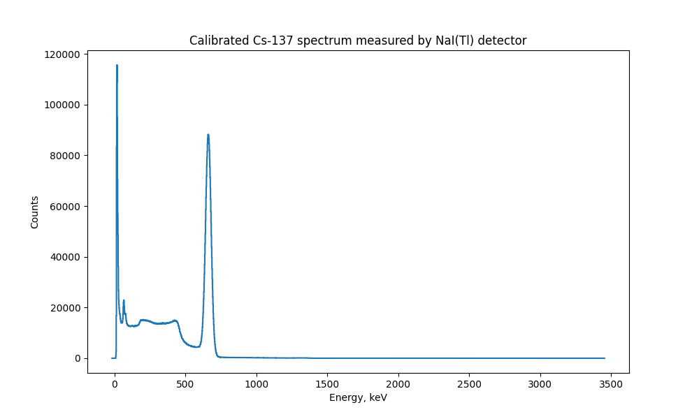

```python
#Execute to make plot of calibrated Cs-137 spectra

#### NO NEED TO EDIT ####
plt.figure(figsize=(10, 6))
# with the data read in with the first routine
plt.step(Cs137.energy, Cs137.counts, where='mid', label='step')
plt.title("Calibrated Cs-137 spectrum measured by NaI(Tl) detector") # set title of the plot
plt.xlabel("Energy, keV")     # set label for x-axis
plt.ylabel("Counts")       # set label for y-axis
#plt.savefig("cs137_calib_spectrum.png") #This is how you save the figure
#########################
```

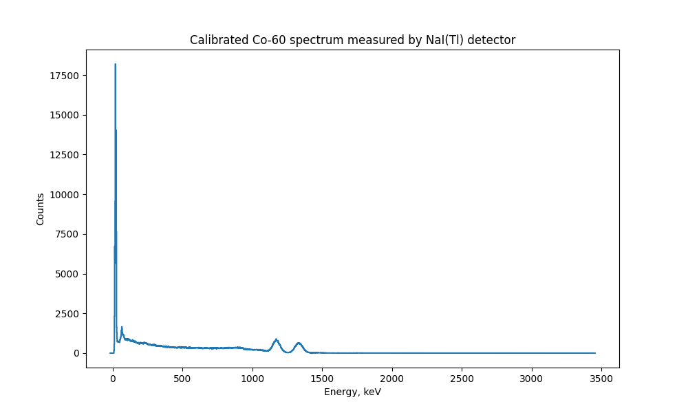

```python
#Execute to make plot of calibrated Co-60 spectra

#### NO NEED TO EDIT ####
plt.figure(figsize=(10, 6))
# with the data read in with the first routine
plt.step(Co60.energy, Co60.counts, where='mid', label='step')

plt.title("Calibrated Co-60 spectrum measured by NaI(Tl) detector") # set title of the plot
plt.xlabel("Energy, keV")     # set label for x-axis
plt.ylabel("Counts")       # set label for y-axis
#plt.savefig("co60_calib_spectrum.png") #This is how you save the figure
#########################
```